# Gas Cost Estimator: estimation of gas costs using the measure marginal method

In this script, there is conducted the estimation for the `measure_marginal` approach for a single given env. The programs is the set of bytecode programs with varying number of opcodes. The measurements are time measurements of program runs or benchmarks. The estimation of each opcode is calculated as the regression against the number of a given opcode in the executed programs.

Parametrization. The evm client name env=nethermind, the file with programs programs=pg_precompiles_full_step5.csv, the file with measurements results=results_precompiles_full_nethermind.csv,  
the output csv file with estimated cost output_estimated_cost=reports/estimated_cost_nethermind_precompiles.csv, should the details be included in the report details=FALSE.

```r
if (removed_outliers) {
  measurements = remove_compare_outliers(measurements, 'measure_total_time_ns', c(env))
}
```

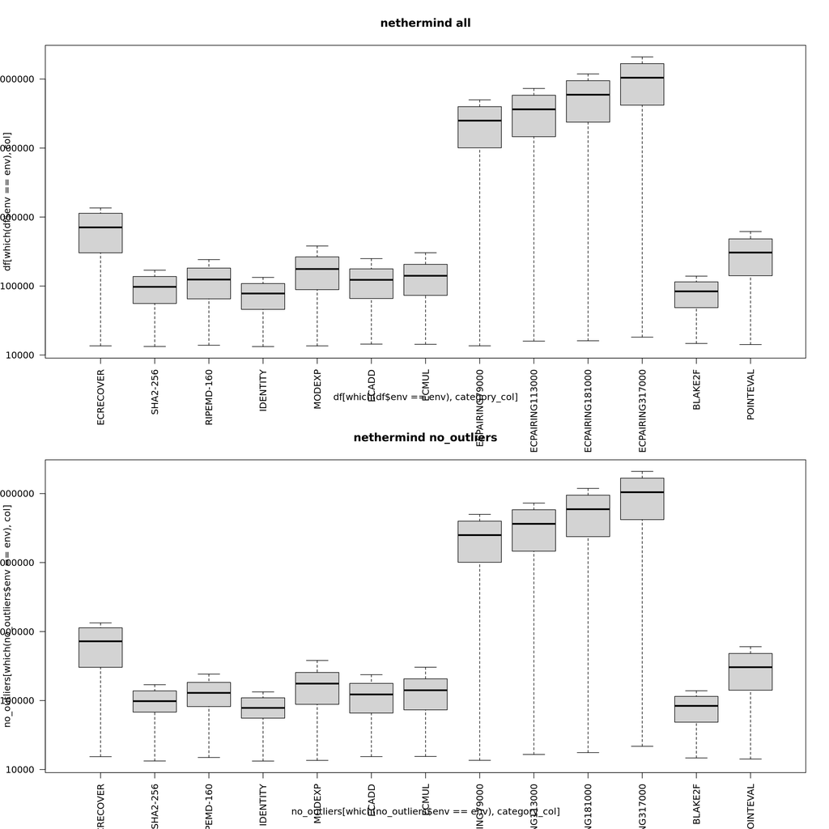

Now we can investigate the linear regressions.

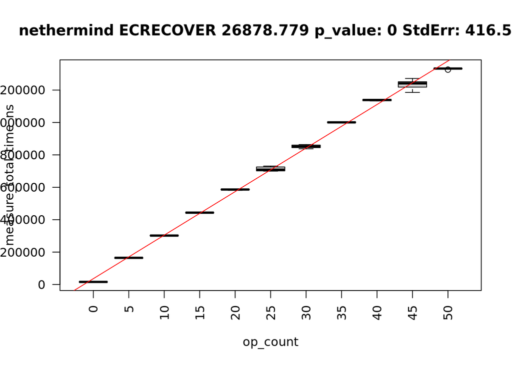

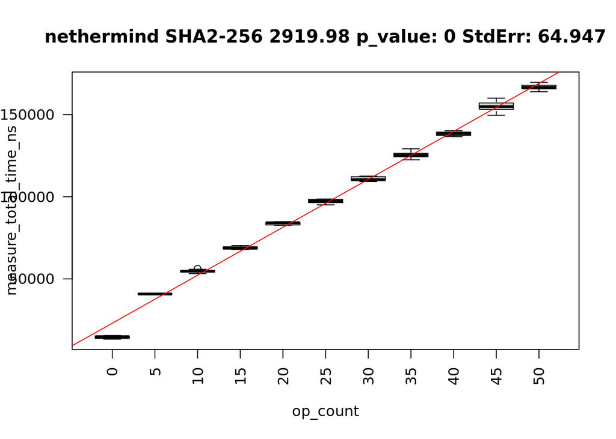

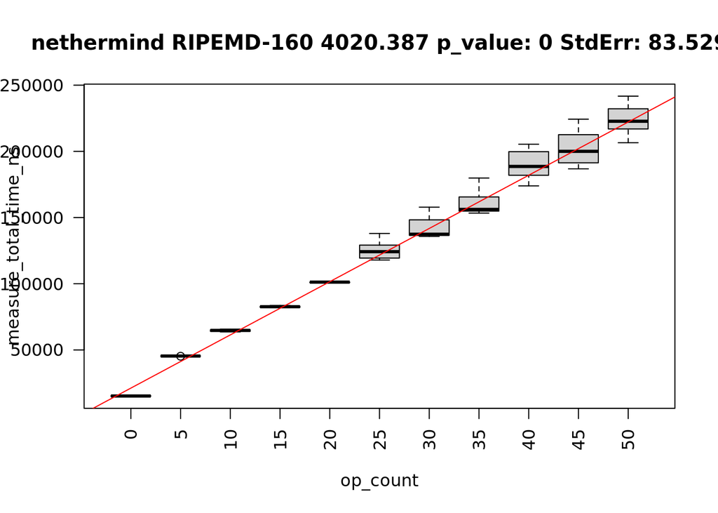

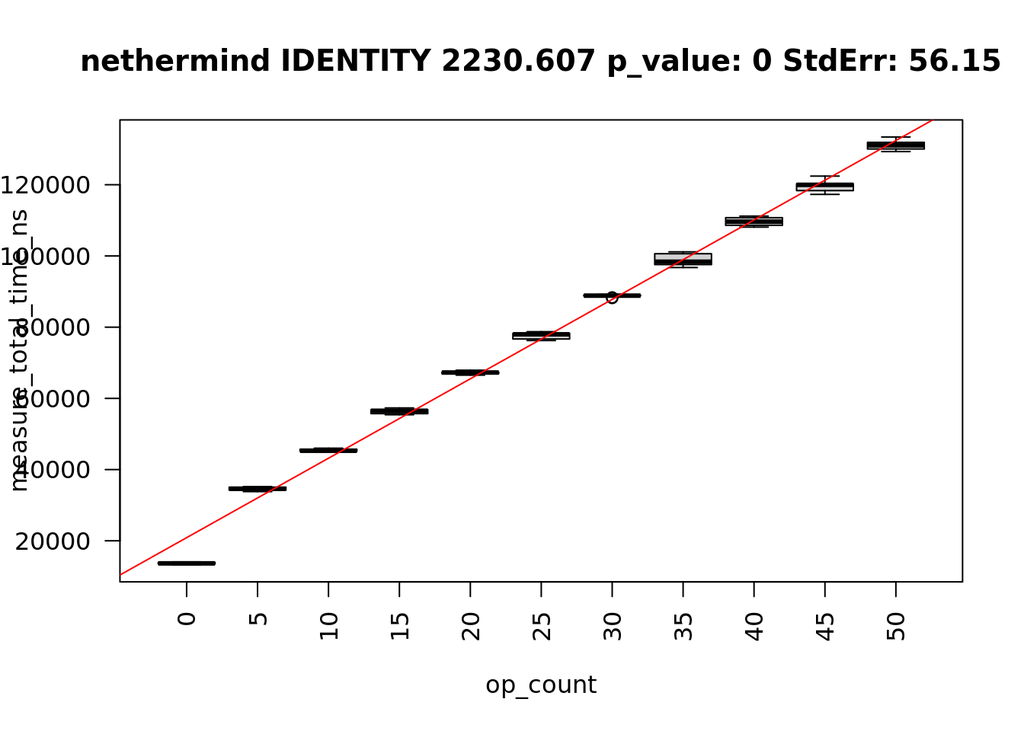

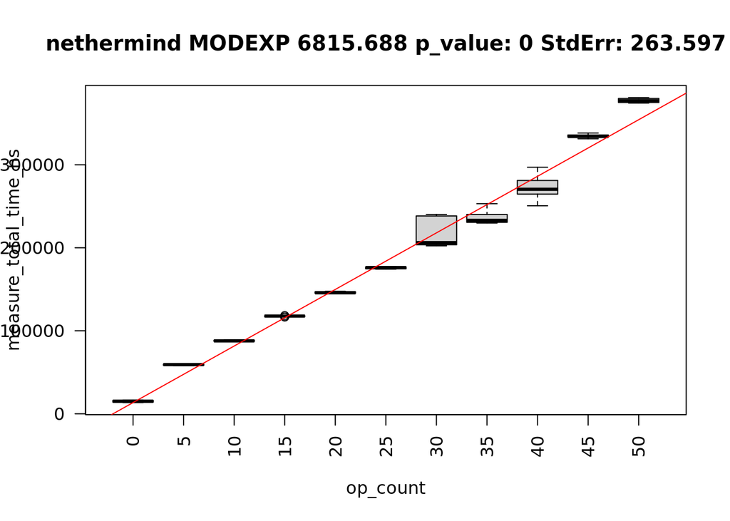

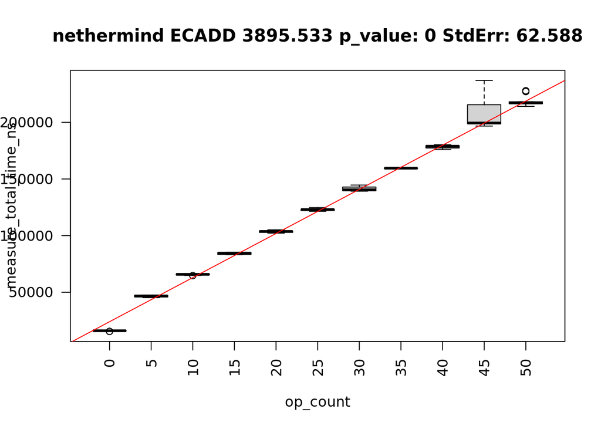

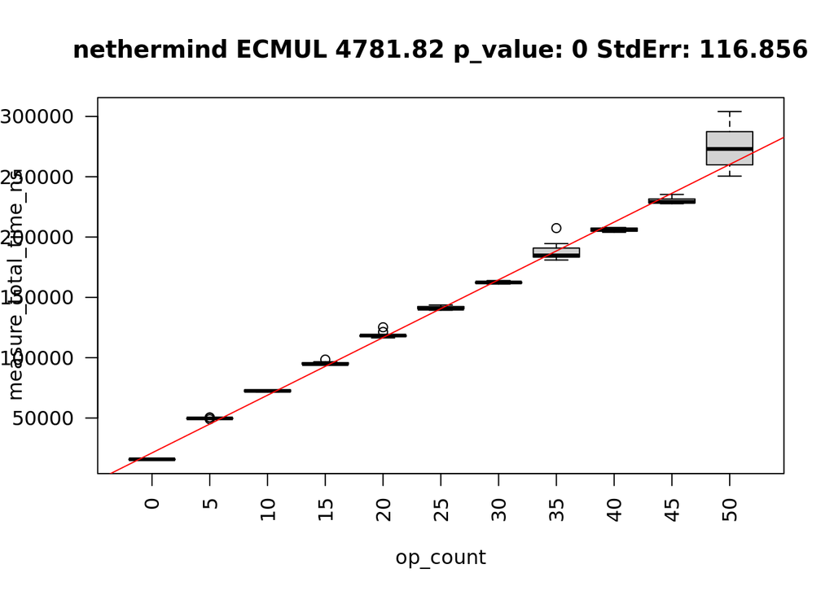

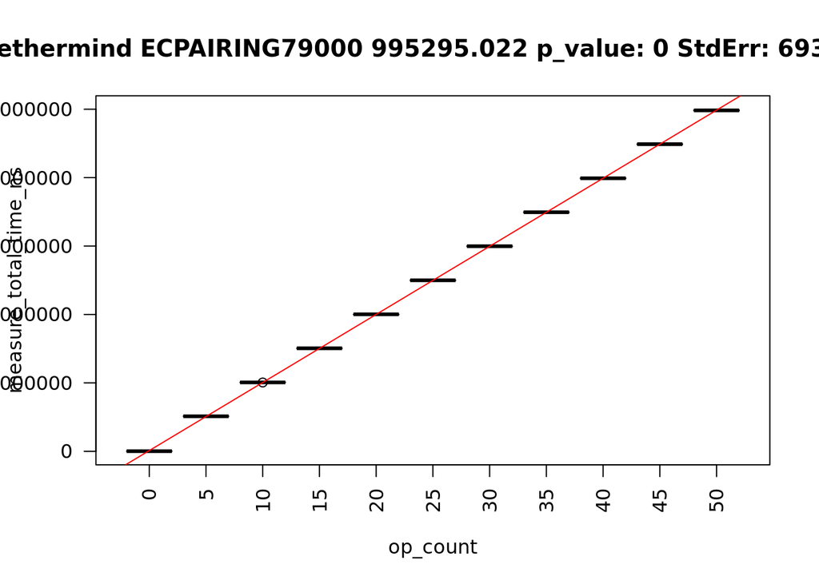

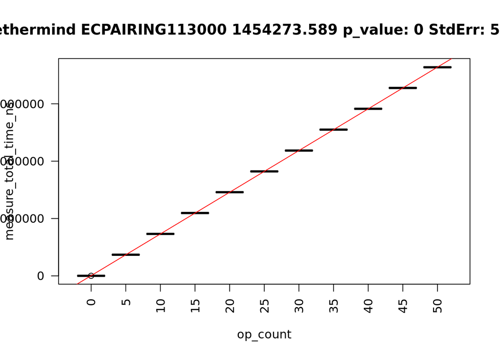

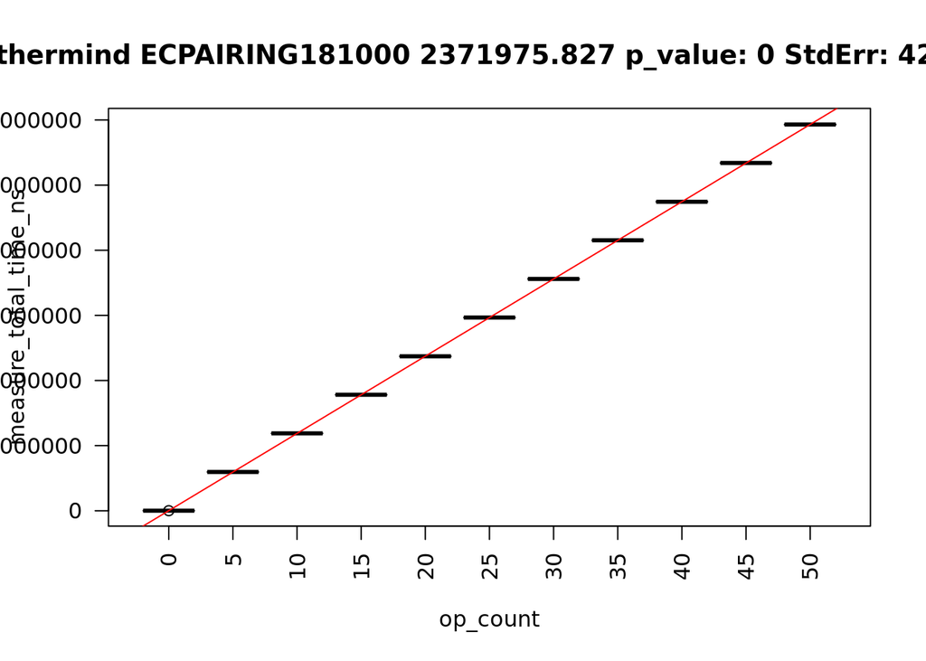

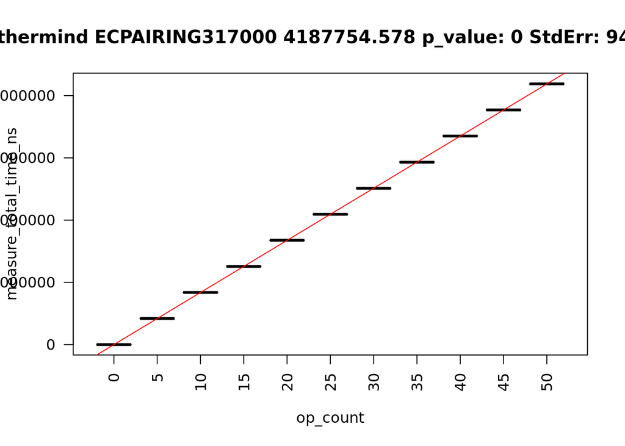

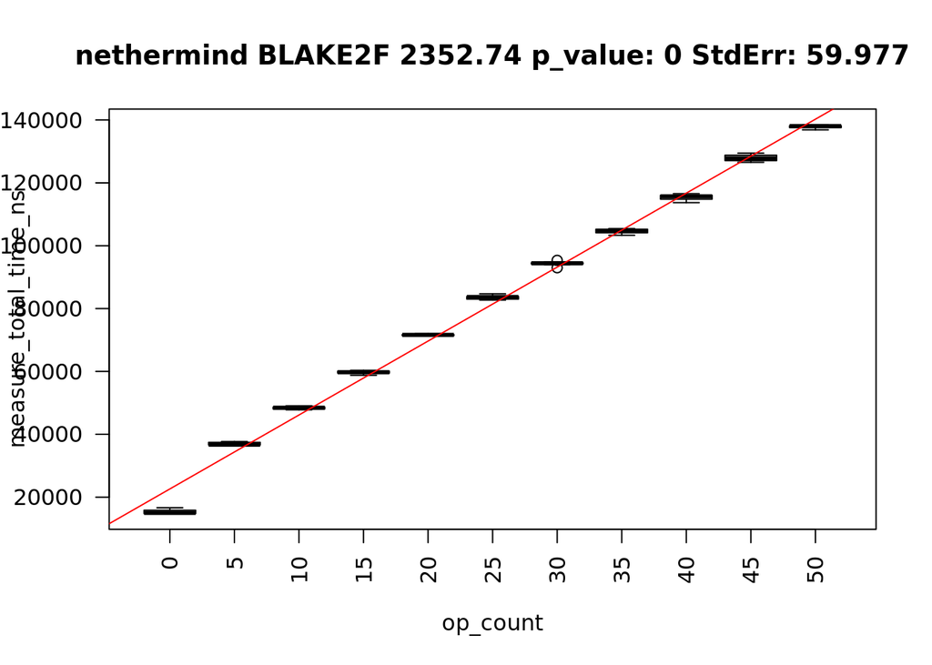

[1 more figures not shown]

```r
for (opcode in all_opcodes) {
  estimate = compute_all(opcode=opcode, env=env, use_median=TRUE, plots=ifelse(details,'all','scatter'))
  estimates[nrow(estimates) + 1, ] = c(opcode, estimate, env)
}
```

The resulting estimates based on the regressions above.

```r
estimates
```

```
##                 op estimate_marginal_ns estimate_marginal_ns_stderr        env
## 1        ECRECOVER            26878.779                   416.58009 nethermind
## 2         SHA2-256             2919.980                    64.94663 nethermind
## 3       RIPEMD-160             4020.387                    83.52910 nethermind
## 4         IDENTITY             2230.607                    56.14988 nethermind
## 5           MODEXP             6815.688                   263.59729 nethermind
## 6            ECADD             3895.533                    62.58768 nethermind
## 7            ECMUL             4781.820                   116.85640 nethermind
## 8   ECPAIRING79000           995295.022                   693.32610 nethermind
## 9  ECPAIRING113000          1454273.589                   551.46975 nethermind
## 10 ECPAIRING181000          2371975.827                   422.27516 nethermind
## 11 ECPAIRING317000          4187754.578                   947.51179 nethermind
## 12         BLAKE2F             2352.740                    59.97664 nethermind
## 13       POINTEVAL            11482.189                    96.15620 nethermind
```

The results are exported to reports/estimated_cost_nethermind_precompiles.csv.